# credit_card_churner_predictor

# Observations between Customer_Age and Gender from the plot below

- Male and female in the dataset does not differ much in age (seems to be evenly distributed)

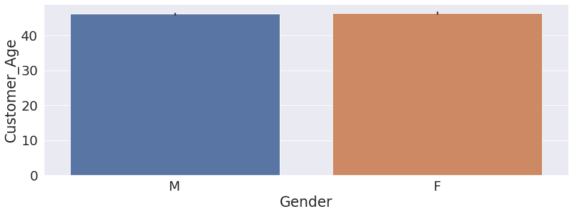

```python
fig, ax = plt.subplots()
fig.set_size_inches(15.7, 5.27)
ax = sns.barplot(y=data['Customer_Age'], x=data['Gender'])
```

# Observations between Customer_Age and Marital_Status from the plot below

- Across 3 types of marital status, age seems to be evenly distributed

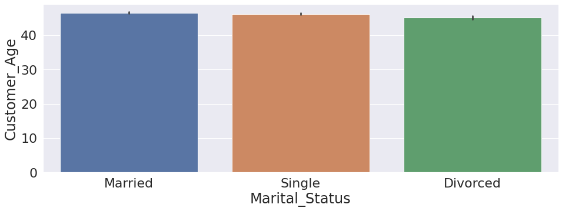

```python
fig, ax = plt.subplots()
fig.set_size_inches(15.7, 5.27)
ax = sns.barplot(y=data['Customer_Age'], x=data['Marital_Status'])
```

# Observations between Customer_Age and Education level from the plot below

- Across 6 types of education level, age seems to be evenly distributed
- Doctorates seems to be of higher age (which makes sense)

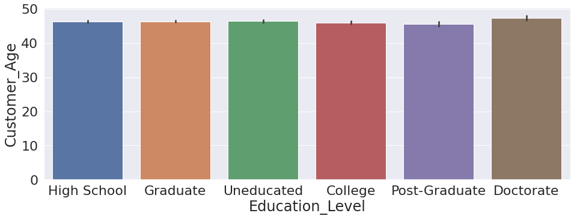

```python
fig, ax = plt.subplots()
fig.set_size_inches(15.7, 5.27)
ax = sns.barplot(y=data['Customer_Age'], x=data['Education_Level'])
```

# Observations between Customer_Age and Income_Category level from the plot below

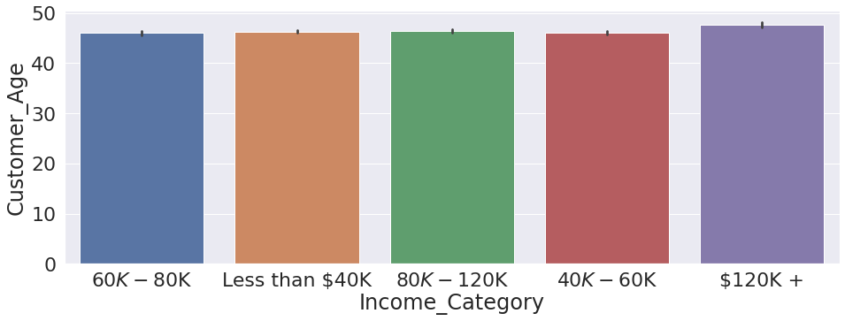

```python
fig, ax = plt.subplots()
fig.set_size_inches(15.7, 5.27)
ax = sns.barplot(y=data['Customer_Age'], x=data['Income_Category'])
```